# HW3

Michael Ippolito

2022-10-16

### Exploratory data analysis

```r
# Load training data
dftrain <- read.csv('https://raw.githubusercontent.com/letisalba/Data_621/master/Homework_3/csv/crime-training-data_modified.csv')

# Summary
summary(dftrain)
```

```
##        zn             indus             chas              nox
##  Min.   :  0.00   Min.   : 0.460   Min.   :0.00000   Min.   :0.3890
##  1st Qu.:  0.00   1st Qu.: 5.145   1st Qu.:0.00000   1st Qu.:0.4480
##  Median :  0.00   Median : 9.690   Median :0.00000   Median :0.5380
##  Mean   : 11.58   Mean   :11.105   Mean   :0.07082   Mean   :0.5543
##  3rd Qu.: 16.25   3rd Qu.:18.100   3rd Qu.:0.00000   3rd Qu.:0.6240
##  Max.   :100.00   Max.   :27.740   Max.   :1.00000   Max.   :0.8710
##        rm             age              dis              rad
##  Min.   :3.863   Min.   :  2.90   Min.   : 1.130   Min.   : 1.00
##  1st Qu.:5.887   1st Qu.: 43.88   1st Qu.: 2.101   1st Qu.: 4.00
##  Median :6.210   Median : 77.15   Median : 3.191   Median : 5.00
##  Mean   :6.291   Mean   : 68.37   Mean   : 3.796   Mean   : 9.53
##  3rd Qu.:6.630   3rd Qu.: 94.10   3rd Qu.: 5.215   3rd Qu.:24.00
##  Max.   :8.780   Max.   :100.00   Max.   :12.127   Max.   :24.00
##       tax           ptratio         lstat             medv
##  Min.   :187.0   Min.   :12.6   Min.   : 1.730   Min.   : 5.00
##  1st Qu.:281.0   1st Qu.:16.9   1st Qu.: 7.043   1st Qu.:17.02
##  Median :334.5   Median :18.9   Median :11.350   Median :21.20
##  Mean   :409.5   Mean   :18.4   Mean   :12.631   Mean   :22.59
##  3rd Qu.:666.0   3rd Qu.:20.2   3rd Qu.:16.930   3rd Qu.:25.00
##  Max.   :711.0   Max.   :22.0   Max.   :37.970   Max.   :50.00
##      target
##  Min.   :0.0000
##  1st Qu.:0.0000
##  Median :0.0000
##  Mean   :0.4914
##  3rd Qu.:1.0000
##  Max.   :1.0000
```

```r
describe(dftrain)
```

```
##         vars   n   mean     sd median trimmed    mad    min    max  range  skew
## zn         1 466  11.58  23.36   0.00    5.35   0.00   0.00 100.00 100.00  2.18
## indus      2 466  11.11   6.85   9.69   10.91   9.34   0.46  27.74  27.28  0.29
## chas       3 466   0.07   0.26   0.00    0.00   0.00   0.00   1.00   1.00  3.34
## nox        4 466   0.55   0.12   0.54    0.54   0.13   0.39   0.87   0.48  0.75
## rm         5 466   6.29   0.70   6.21    6.26   0.52   3.86   8.78   4.92  0.48
## age        6 466  68.37  28.32  77.15   70.96  30.02   2.90 100.00  97.10 -0.58
## dis        7 466   3.80   2.11   3.19    3.54   1.91   1.13  12.13  11.00  1.00
## rad        8 466   9.53   8.69   5.00    8.70   1.48   1.00  24.00  23.00  1.01
## tax        9 466 409.50 167.90 334.50  401.51 104.52 187.00 711.00 524.00  0.66
## ptratio   10 466  18.40   2.20  18.90   18.60   1.93  12.60  22.00   9.40 -0.75
## lstat     11 466  12.63   7.10  11.35   11.88   7.07   1.73  37.97  36.24  0.91
## medv      12 466  22.59   9.24  21.20   21.63   6.00   5.00  50.00  45.00  1.08
## target    13 466   0.49   0.50   0.00    0.49   0.00   0.00   1.00   1.00  0.03
##         kurtosis   se
## zn          3.81 1.08
## indus      -1.24 0.32
## chas        9.15 0.01
## nox        -0.04 0.01
## rm          1.54 0.03
## age        -1.01 1.31
## dis         0.47 0.10
## rad        -0.86 0.40
## tax        -1.15 7.78
## ptratio    -0.40 0.10
## lstat       0.50 0.33
## medv        1.37 0.43
## target     -2.00 0.02
```

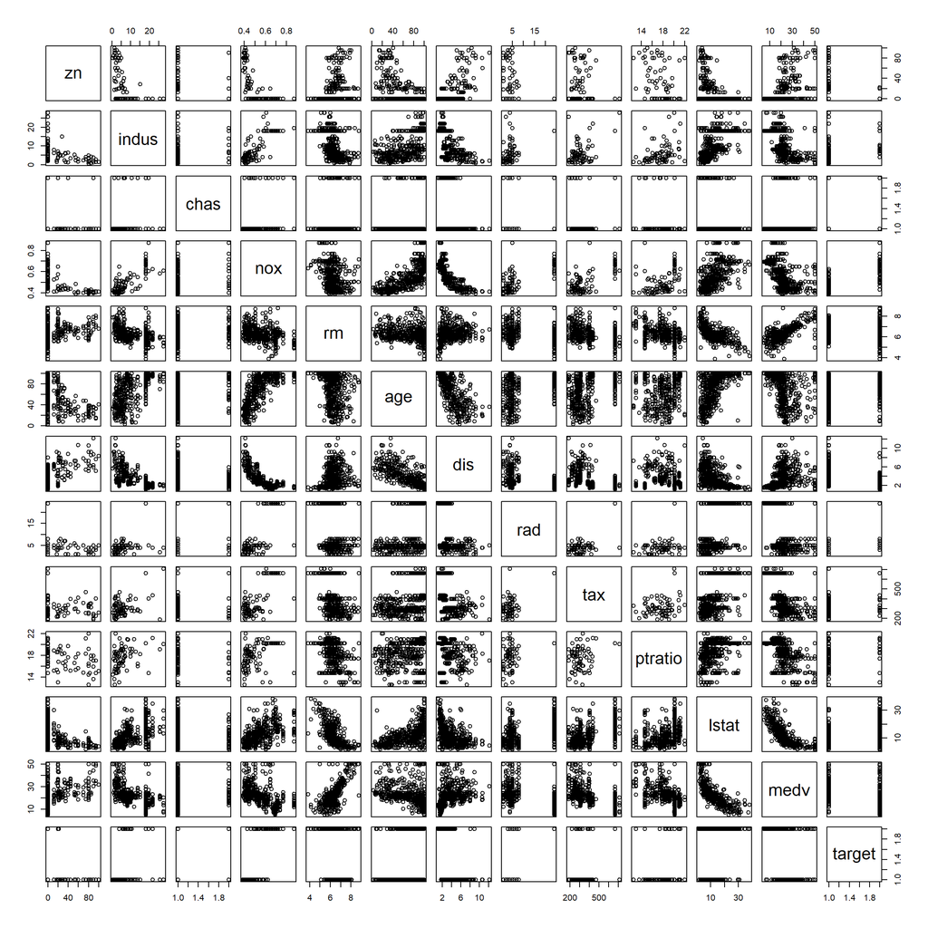

```r
# Factor categorical variables
dftrain$target <- factor(dftrain$target, levels=c(0, 1), labels=c('below_median', 'above_median'))
dftrain$chas <- factor(dftrain$chas)
levels(dftrain$chas) <- list(not_on_charles=0, on_charles=1)

# EDA
pairs(dftrain)
```

```r
# Boxplots
par(mfrow=c(4, 3))
boxplot(zn ~ target, data=dftrain)
boxplot(indus ~ target, data=dftrain)
#boxplot(chas ~ target, data=dftrain)
boxplot(nox ~ target, data=dftrain)
boxplot(rm ~ target, data=dftrain)
boxplot(age ~ target, data=dftrain)
boxplot(dis ~ target, data=dftrain)
boxplot(rad ~ target, data=dftrain)
boxplot(tax ~ target, data=dftrain)
boxplot(ptratio ~ target, data=dftrain)
boxplot(lstat ~ target, data=dftrain)
boxplot(medv ~ target, data=dftrain)

# Contingency table and jittered plot for chas variable
dfconting <- data.frame(target=dftrain$target, chas=dftrain$chas)
table(dfconting)
```

```
##               chas
## target         not_on_charles on_charles
##   below_median            225         12
##   above_median            208         21
```

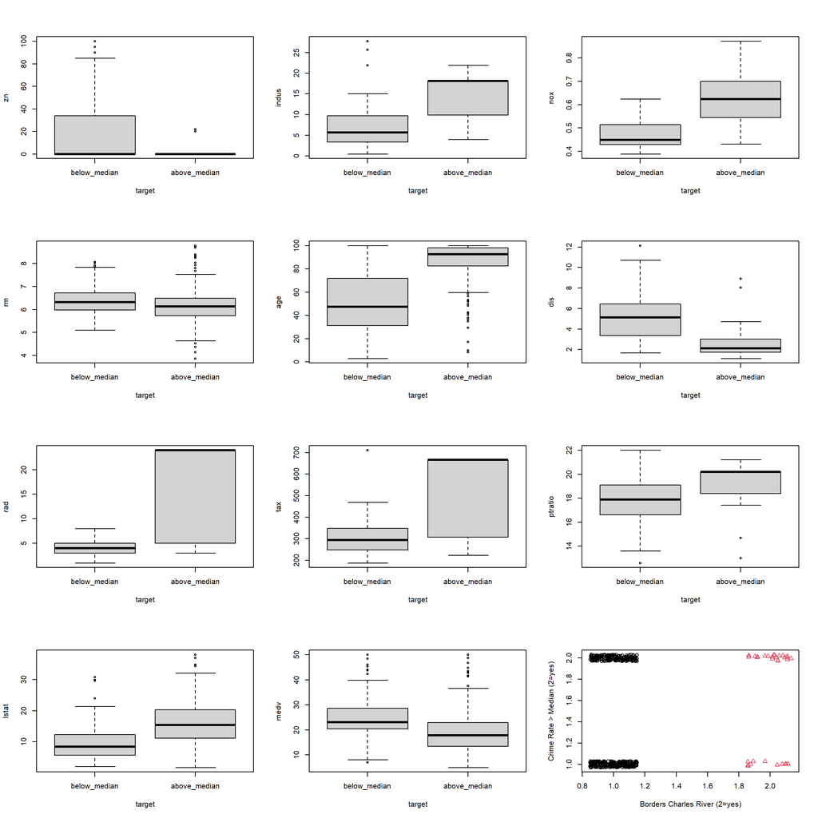

```r
plot(jitter(as.numeric(dftrain$chas), amount=.15), jitter(as.numeric(dftrain$target), amount=0.03),
     xlab="Borders Charles River (2=yes)", ylab="Crime Rate > Median (2=yes)", col=dftrain$chas, pch=as.numeric(dftrain$chas))
```

Relationship of median crime rate to the following predictor variables:

| Predictor | Definition | Relationship to Median Crim Rate |
| --- | --- | --- |
| zn | Proportion of residential land zoned for large lots (over 25000 square feet) | negative |
| indus | Proportion of non-retail business acres per suburb | positive |
| chas | Dummy var. for whether the suburb borders the Charles River | unclear |
| nox | Nitrogen oxides concentration | positive |
| rm | Average number of rooms per dwelling | unclear |
| age | Proportion of owner-occupied units built prior to 1940 | positive |
| dis | Weighted mean of distances to five Boston employment centers | negative |
| rad | Index of accessibility to radial highways | positive |
| tax | Full-value property-tax rate per $10,000 | positive |
| ptratio | Pupil-teacher ratio by town | positive |
| lstat | Lower status of the population (percent) | positive |
| medv | Median value of owner-occupied homes in $1000s | negative |

As indicated in the table, several predictors exhibit exhibite an inverse relationship with median crime rate. Based on the zn and medv variables, larger lot sizes and higher median home values correspond to a drop in crime rate, which is expected since larger lots and higher home values typically indicate higher economic status and, hence, lower crime. The same is true for the dis variable, which indicates that the farther a neighborhood is away from a major employment center, the lower the crime rate; this also makes sense, given that employment centers are often located in denser, more urban settings, which typically have higher rates of crime.

For the most part, variables exhibiting positive relationships with median crime rate also make intuitive sense. It would follow that neighborhoods having higher rates of industry (and, therefore, higher concentrations of pollutants like nitrogen oxides–nox–in the air) would also have higher crime rates. Likewise, neighborhoods with older homes (indicated by the age variable) located near radial highways (rad variable) and with a high pupil-to-teacher ratio (ptratio variable) could also be interpreted to have higher rates of crime.

Two variables didn’t exhibit a clear relationships to crime rate: whether the neighborhood borders the Charles River (chas) and the average number of rooms per dwelling (rm). In addition, while the the lstat predictor exhibitied a positive relationship with crime rate, the description of the variable (“lower status of the population”) didn’t clearly state what the data values represent.

### Explore colinearity of predictor variables

Now we’ll look for any significant relationships among predictor variables. We considered correlation values above 0.6 to be significant.

```r
# Correlation matrix
print('Correlation matrix (numerical variables):')
```

```
## [1] "Correlation matrix (numerical variables):"
```

```r
round(cor(dftrain[, c(1,2,4:12)]), 2)
```

```
##            zn indus   nox    rm   age   dis   rad   tax ptratio lstat  medv
## zn       1.00 -0.54 -0.52  0.32 -0.57  0.66 -0.32 -0.32   -0.39 -0.43  0.38
## indus   -0.54  1.00  0.76 -0.39  0.64 -0.70  0.60  0.73    0.39  0.61 -0.50
## nox     -0.52  0.76  1.00 -0.30  0.74 -0.77  0.60  0.65    0.18  0.60 -0.43
## rm       0.32 -0.39 -0.30  1.00 -0.23  0.20 -0.21 -0.30   -0.36 -0.63  0.71
## age     -0.57  0.64  0.74 -0.23  1.00 -0.75  0.46  0.51    0.26  0.61 -0.38
## dis      0.66 -0.70 -0.77  0.20 -0.75  1.00 -0.49 -0.53   -0.23 -0.51  0.26
## rad     -0.32  0.60  0.60 -0.21  0.46 -0.49  1.00  0.91    0.47  0.50 -0.40
## tax     -0.32  0.73  0.65 -0.30  0.51 -0.53  0.91  1.00    0.47  0.56 -0.49
## ptratio -0.39  0.39  0.18 -0.36  0.26 -0.23  0.47  0.47    1.00  0.38 -0.52
## lstat   -0.43  0.61  0.60 -0.63  0.61 -0.51  0.50  0.56    0.38  1.00 -0.74
## medv     0.38 -0.50 -0.43  0.71 -0.38  0.26 -0.40 -0.49   -0.52 -0.74  1.00
```

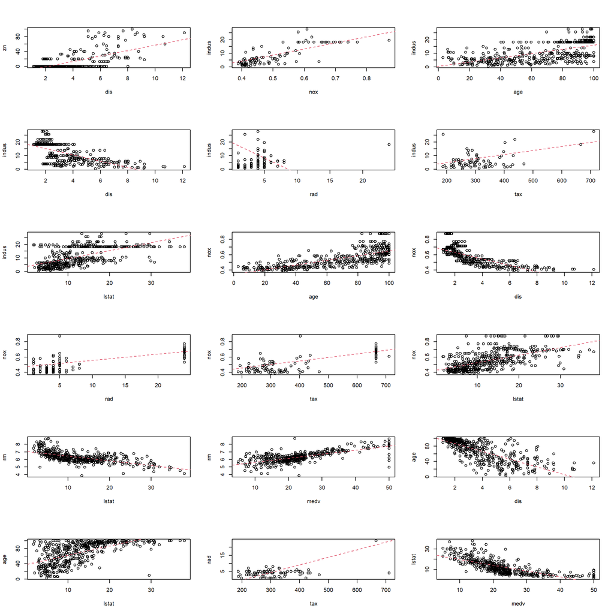

```r
par(mfrow=c(6, 3))

plot(zn ~ dis, data=dftrain)
abline(lm(zn ~ dis, data=dftrain), lt=2, col=2)

plot(indus ~ nox, data=dftrain)
abline(lm(indus ~ nox, dftrain), lt=2, col=2)

plot(indus ~ age, data=dftrain)
abline(lm(indus ~ age, dftrain), lt=2, col=2)

plot(indus ~ dis, data=dftrain)
abline(lm(indus ~ dis, dftrain), lt=2, col=2)

plot(indus ~ rad, data=dftrain)
abline(lm(indus ~ dis, dftrain), lt=2, col=2)

plot(indus ~ tax, data=dftrain)
abline(lm(indus ~ tax, dftrain), lt=2, col=2)

plot(indus ~ lstat, data=dftrain)
abline(lm(indus ~ lstat, dftrain), lt=2, col=2)

plot(nox ~ age, data=dftrain)
abline(lm(nox ~ age, dftrain), lt=2, col=2)

plot(nox ~ dis, data=dftrain)
abline(lm(nox ~ dis, dftrain), lt=2, col=2)

plot(nox ~ rad, data=dftrain)
abline(lm(nox ~ rad, dftrain), lt=2, col=2)

plot(nox ~ tax, data=dftrain)
abline(lm(nox ~ tax, dftrain), lt=2, col=2)

plot(nox ~ lstat, data=dftrain)
abline(lm(nox ~ lstat, dftrain), lt=2, col=2)

plot(rm ~ lstat, data=dftrain)
abline(lm(rm ~ lstat, dftrain), lt=2, col=2)

plot(rm ~ medv, data=dftrain)
abline(lm(rm ~ medv, dftrain), lt=2, col=2)

plot(age ~ dis, data=dftrain)
abline(lm(age ~ dis, dftrain), lt=2, col=2)

plot(age ~ lstat, data=dftrain)
abline(lm(age ~ lstat, dftrain), lt=2, col=2)

plot(rad ~ tax, data=dftrain)
abline(lm(rad ~ tax, dftrain), lt=2, col=2)

plot(lstat ~ medv, data=dftrain)
abline(lm(lstat ~ medv, dftrain), lt=2, col=2)
```

As shown in the graphs, a number of significant correlations exist. Some of the stronger relationships are discussed here. Frist, the proportion of area zoned for large lots (zn) has a positive relationship with the distance to employment centers (dis), since it is more difficult to locate large lots close to the city center. A strong positive correlation exists between indus and nox, which is intuitively obvious. Likewise, tax rates in industrial areas are likely to be higher, as shown by the strong positive correlation of 0.73. Another strong correlation that makes obvious intuitive sense is that between median home values (medv) and the average number of rooms per dwelling (rm). The strongest positive correlation (0.91) exists between tax rate (tax) and the index of accessibility to radial highways (rad), which also corresponds to the fact that industrial areas are typically close to radial highways and also exhibit higher tax rates. The strongest negative correlation (-0.77) exists between nox and dis, indicating that the farther away from employment centers (and, hence, industrial areas), the lower the concentration of nitrogen oxide pollutants. Almost equally strong (-0.75) is the correlation between the age of dwellings (age) and the distance from employment centers (dis), indicating that the farther from urban centers, the newer the houses, which makes intuitive sense.

### Logistic regression

```r
# Maximal model for backward elimination
lmod.max <- glm(target ~ ., family=binomial(), data=dftrain)
summary(lmod.max)
```

```
##
## Call:
## glm(formula = target ~ ., family = binomial(), data = dftrain)
##
## Deviance Residuals:
##     Min       1Q   Median       3Q      Max
## -1.8464  -0.1445  -0.0017   0.0029   3.4665
##
## Coefficients:
##                  Estimate Std. Error z value Pr(>|z|)
## (Intercept)    -40.822934   6.632913  -6.155 7.53e-10 ***
## zn              -0.065946   0.034656  -1.903  0.05706 .
## indus           -0.064614   0.047622  -1.357  0.17485
## chason_charles   0.910765   0.755546   1.205  0.22803
## nox             49.122297   7.931706   6.193 5.90e-10 ***
## rm              -0.587488   0.722847  -0.813  0.41637
## age              0.034189   0.013814   2.475  0.01333 *
## dis              0.738660   0.230275   3.208  0.00134 **
## rad              0.666366   0.163152   4.084 4.42e-05 ***
## tax             -0.006171   0.002955  -2.089  0.03674 *
## ptratio          0.402566   0.126627   3.179  0.00148 **
## lstat            0.045869   0.054049   0.849  0.39608
## medv             0.180824   0.068294   2.648  0.00810 **
## ---
## Signif. codes:  0 '***' 0.001 '**' 0.01 '*' 0.05 '.' 0.1 ' ' 1
##
## (Dispersion parameter for binomial family taken to be 1)
##
##     Null deviance: 645.88  on 465  degrees of freedom
## Residual deviance: 192.05  on 453  degrees of freedom
## AIC: 218.05
##
## Number of Fisher Scoring iterations: 9
```

```r
# Backward elimination
lmod.back <- step(lmod.max, data=dftrain, direction='backward')
```

```
## Start:  AIC=218.05
## target ~ zn + indus + chas + nox + rm + age + dis + rad + tax +
##     ptratio + lstat + medv
##
##           Df Deviance    AIC
## - rm       1   192.71 216.71
## - lstat    1   192.77 216.77
## - chas     1   193.53 217.53
## - indus    1   193.99 217.99
## <none>         192.05 218.05
## - tax      1   196.59 220.59
## - zn       1   196.89 220.89
## - age      1   198.73 222.73
## - medv     1   199.95 223.95
## - ptratio  1   203.32 227.32
## - dis      1   203.84 227.84
## - rad      1   233.74 257.74
## - nox      1   265.05 289.05
##
## Step:  AIC=216.71
## target ~ zn + indus + chas + nox + age + dis + rad + tax + ptratio +
##     lstat + medv
##
##           Df Deviance    AIC
## - chas     1   194.24 216.24
## - lstat    1   194.32 216.32
## - indus    1   194.58 216.58
## <none>         192.71 216.71
## - tax      1   197.59 219.59
## - zn       1   198.07 220.07
## - age      1   199.11 221.11
## - ptratio  1   203.53 225.53
## - dis      1   203.85 225.85
## - medv     1   205.35 227.35
## - rad      1   233.81 255.81
## - nox      1   265.14 287.14
##
## Step:  AIC=216.24
## target ~ zn + indus + nox + age + dis + rad + tax + ptratio +
##     lstat + medv
```

[output cut: 28 more lines]

```
## - nox      1   270.59 288.59
##
## Step:  AIC=215.32
## target ~ zn + nox + age + dis + rad + tax + ptratio + medv
##
##           Df Deviance    AIC
## <none>         197.32 215.32
## - zn       1   203.45 219.45
## - ptratio  1   206.27 222.27
## - age      1   207.13 223.13
## - tax      1   207.62 223.62
## - dis      1   207.64 223.64
## - medv     1   208.65 224.65
## - rad      1   250.98 266.98
## - nox      1   273.18 289.18
```

```r
summary(lmod.back)
```

```
##
## Call:
## glm(formula = target ~ zn + nox + age + dis + rad + tax + ptratio +
##     medv, family = binomial(), data = dftrain)
##
## Deviance Residuals:
##     Min       1Q   Median       3Q      Max
## -1.8295  -0.1752  -0.0021   0.0032   3.4191
##
## Coefficients:
##               Estimate Std. Error z value Pr(>|z|)
## (Intercept) -37.415922   6.035013  -6.200 5.65e-10 ***
## zn           -0.068648   0.032019  -2.144  0.03203 *
## nox          42.807768   6.678692   6.410 1.46e-10 ***
## age           0.032950   0.010951   3.009  0.00262 **
## dis           0.654896   0.214050   3.060  0.00222 **
## rad           0.725109   0.149788   4.841 1.29e-06 ***
## tax          -0.007756   0.002653  -2.924  0.00346 **
## ptratio       0.323628   0.111390   2.905  0.00367 **
## medv          0.110472   0.035445   3.117  0.00183 **
## ---
## Signif. codes:  0 '***' 0.001 '**' 0.01 '*' 0.05 '.' 0.1 ' ' 1
##
## (Dispersion parameter for binomial family taken to be 1)
##
##     Null deviance: 645.88  on 465  degrees of freedom
## Residual deviance: 197.32  on 457  degrees of freedom
## AIC: 215.32
##
## Number of Fisher Scoring iterations: 9
```

```r
# Minimal model for forward elimination
lmod.min <- glm(target ~ 1, family=binomial(), data=dftrain)
summary(lmod.min)
```

```
##
## Call:
## glm(formula = target ~ 1, family = binomial(), data = dftrain)
##
## Deviance Residuals:
##    Min      1Q  Median      3Q     Max
## -1.163  -1.163  -1.163   1.192   1.192
##
## Coefficients:
##             Estimate Std. Error z value Pr(>|z|)
## (Intercept) -0.03434    0.09266  -0.371    0.711
##
## (Dispersion parameter for binomial family taken to be 1)
##
##     Null deviance: 645.88  on 465  degrees of freedom
## Residual deviance: 645.88  on 465  degrees of freedom
## AIC: 647.88
##
## Number of Fisher Scoring iterations: 3
```

```r
lmod.max.form <- formula(lmod.max)

# Forward elimination
lmod.fwd <- step(lmod.min, data=dftrain, direction='forward', scope=lmod.max.form)
```

```
## Start:  AIC=647.88
## target ~ 1
##
##           Df Deviance    AIC
## + nox      1   292.01 296.01
## + rad      1   404.16 408.16
## + dis      1   409.50 413.50
## + age      1   424.75 428.75
## + tax      1   442.38 446.38
## + indus    1   453.23 457.23
## + zn       1   518.46 522.46
## + lstat    1   528.01 532.01
## + medv     1   609.62 613.62
## + ptratio  1   615.64 619.64
## + rm       1   634.82 638.82
## + chas     1   642.86 646.86
## <none>         645.88 647.88
##
## Step:  AIC=296.01
## target ~ nox
##
##           Df Deviance    AIC
## + rad      1   239.51 245.51
## + rm       1   284.63 290.63
## + medv     1   285.86 291.86
## + indus    1   288.11 294.11
## + zn       1   288.29 294.29
## + tax      1   288.40 294.40
## + chas     1   288.47 294.47
## <none>         292.01 296.01
## + ptratio  1   290.13 296.13
## + age      1   290.62 296.62
## + dis      1   290.91 296.91
## + lstat    1   291.93 297.93
##
## Step:  AIC=245.51
## target ~ nox + rad
##
##           Df Deviance    AIC
## + tax      1   224.47 232.47
```

[output cut: 70 more lines]

```
## + chas   1   201.29 219.29
## + rm     1   201.35 219.35
## <none>       203.45 219.45
## + lstat  1   202.05 220.05
## + indus  1   202.23 220.23
##
## Step:  AIC=215.32
## target ~ nox + rad + tax + ptratio + age + medv + dis + zn
##
##         Df Deviance    AIC
## <none>       197.32 215.32
## + lstat  1   195.51 215.51
## + rm     1   195.75 215.75
## + chas   1   195.97 215.97
## + indus  1   196.33 216.33
```

```r
summary(lmod.fwd)
```

```
##
## Call:
## glm(formula = target ~ nox + rad + tax + ptratio + age + medv +
##     dis + zn, family = binomial(), data = dftrain)
##
## Deviance Residuals:
##     Min       1Q   Median       3Q      Max
## -1.8295  -0.1752  -0.0021   0.0032   3.4191
##
## Coefficients:
##               Estimate Std. Error z value Pr(>|z|)
## (Intercept) -37.415922   6.035013  -6.200 5.65e-10 ***
## nox          42.807768   6.678692   6.410 1.46e-10 ***
## rad           0.725109   0.149788   4.841 1.29e-06 ***
## tax          -0.007756   0.002653  -2.924  0.00346 **
## ptratio       0.323628   0.111390   2.905  0.00367 **
## age           0.032950   0.010951   3.009  0.00262 **
## medv          0.110472   0.035445   3.117  0.00183 **
## dis           0.654896   0.214050   3.060  0.00222 **
## zn           -0.068648   0.032019  -2.144  0.03203 *
## ---
## Signif. codes:  0 '***' 0.001 '**' 0.01 '*' 0.05 '.' 0.1 ' ' 1
##
## (Dispersion parameter for binomial family taken to be 1)
##
##     Null deviance: 645.88  on 465  degrees of freedom
## Residual deviance: 197.32  on 457  degrees of freedom
## AIC: 215.32
##
## Number of Fisher Scoring iterations: 9
```

### Model selection

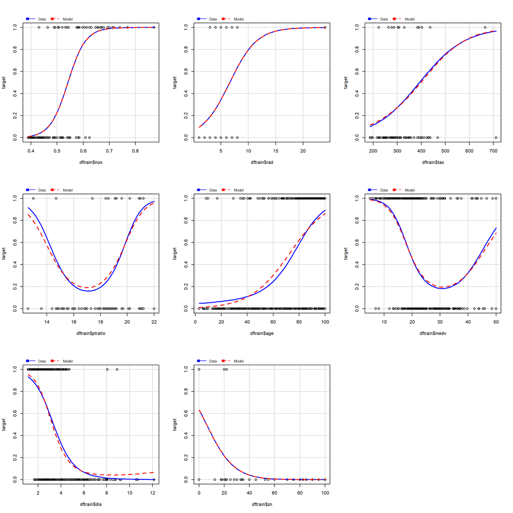

```r
# Marginal model plots
par(mfrow=c(3, 3))
mmp(lmod.fwd, dftrain$nox)
mmp(lmod.fwd, dftrain$rad)
mmp(lmod.fwd, dftrain$tax)
mmp(lmod.fwd, dftrain$ptratio)
mmp(lmod.fwd, dftrain$age)
mmp(lmod.fwd, dftrain$medv)
mmp(lmod.fwd, dftrain$dis)
mmp(lmod.fwd, dftrain$zn)

# Find leverage points
p <- length(lmod.fwd$coefficients) - 1
n <- nrow(dftrain)
hvals <- hatvalues(lmod.fwd)
stanresDeviance <- residuals(lmod.fwd) / sqrt(1 - hvals)
plot.new()
```

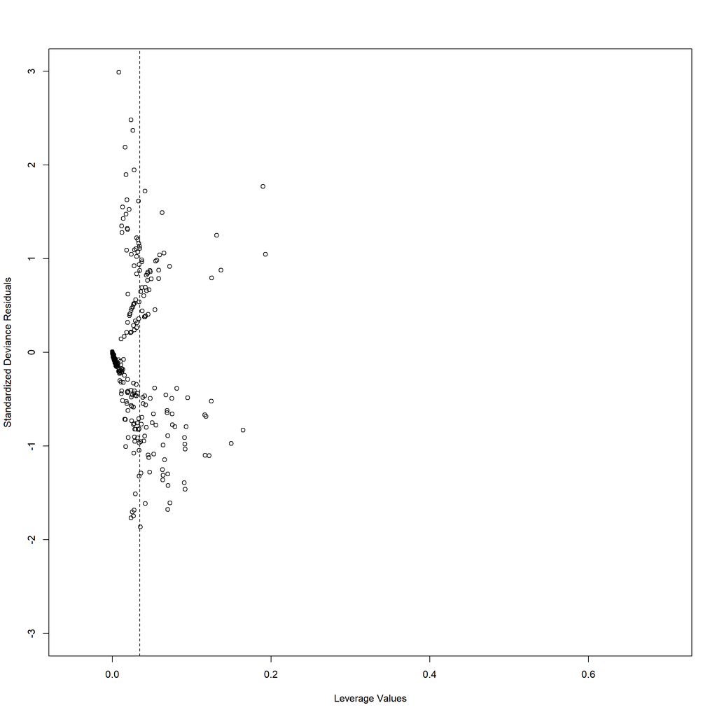

```r
par(mfrow=c(1, 1))
plot(hvals, stanresDeviance, ylab="Standardized Deviance Residuals", xlab="Leverage Values", ylim=c(-3,3), xlim=c(-0.05,0.7))
abline(v=2*p/n, lty=2)
```

```r
#tmp <- identify(hvals, stanresDeviance, labels=dftrain$target, cex=0.75, plot=T, n=3, pos=T)

# Pearson's chi-squared - goodness of fit test
chisq <- sum(residuals(lmod.fwd, type="pearson")^2)
print(paste0('Pearson\'s chi-squared: ', chisq))
```

```
## [1] "Pearson's chi-squared: 598.773072176156"
```

```r
pval <- pchisq(chisq, lmod.fwd$df.residual, lower.tail=F)
print(paste0("P-value: ", pval))
```

```
## [1] "P-value: 8.59996828254721e-06"
```

```r
# Functions to return model scoring metrics

# Accuracy
func.accuracy <- function (df, actual, predict) {
    return(sum(df[actual] == df[predict]) / nrow(df))
}

# Error rate
func.error_rate <- function(df, actual, predict) {
    return(sum(df[actual] != df[predict]) / nrow(df))
}

# Precision
func.precision <- function(df, actual, predict) {
    TP <- sum(as.numeric(df[[actual]]) == 2 & as.numeric(df[[actual]]) == 2)
    FP <- sum(as.numeric(df[[actual]]) == 1 & as.numeric(df[[predict]]) == 2)
    return(TP / (TP + FP))
}

# Sensitivity
func.sensitivity <- function(df, actual, predict) {
    TP <- sum(as.numeric(df[[actual]]) == 2 & as.numeric(df[[predict]]) == 2)
    FN <- sum(as.numeric(df[[actual]]) == 2 & as.numeric(df[[predict]]) == 1)
    return(TP / (TP + FN))
}

# Specificity
func.specificity <- function(df, actual, predict) {
    TN <- sum(as.numeric(df[[actual]]) == 1 & as.numeric(df[[predict]]) == 1)
    FP <- sum(as.numeric(df[[actual]]) == 1 & as.numeric(df[[predict]]) == 2)
    return(TN / (TN + FP))
}

# ROC curve
func.ROC <- function(df, pred_p, actual) {
    tpr <- c()
    fpr <- c()
    for (i in seq(0, 1, 0.01)) {
        df$pred_target = ifelse(df[[pred_p]] > i, 2, 1)
        predict = 'pred_target'
        df$TP <- as.vector(ifelse(as.numeric(df[[actual]]) == 2 & as.numeric(df[[predict]]) == 2, 1, 0))
        df$TN <- as.vector(ifelse(as.numeric(df[[actual]]) == 1 & as.numeric(df[[predict]]) == 1, 1, 0))
        df$FP <- as.vector(ifelse(as.numeric(df[[actual]]) == 1 & as.numeric(df[[predict]]) == 2, 1, 0))
        df$FN <- as.vector(ifelse(as.numeric(df[[actual]]) == 2 & as.numeric(df[[predict]]) == 1, 1, 0))
        tpr <- c(tpr, sum(df$TP) / (sum(df$TP) + sum(df$FN)))
        fpr <- c(fpr, sum(df$FP) / (sum(df$FP) + sum(df$TN)))
    }
    print(df)
    plot(tpr ~ fpr, type='l', xlim=c(0, 1), ylim=c(0, 1))
    abline(a=0, b=1, lt=2, col=2, xlim=c(0, 1), ylim=c(0, 1))
}
```

### Predictions

```r
# Make predictions on training set
dftrain$pred_odds <- predict(lmod.fwd, newdata=dftrain)
dftrain$pred_p <- ilogit(dftrain$pred_odds)
dftrain$pred_target <- ifelse(dftrain$pred_p > 0.5, 1, 0)
dftrain$pred_target <- factor(dftrain$pred_target, levels=c(0, 1), labels=c('below_median', 'above_median'))
model_accuracy <- func.accuracy(dftrain, 'target', 'pred_target')
model_error_rate <- func.error_rate(dftrain, 'target', 'pred_target')
model_precision <- func.precision(dftrain, 'target', 'pred_target')
model_sensitivity <- func.sensitivity(dftrain, 'target', 'pred_target')
model_specificity <- func.specificity(dftrain, 'target', 'pred_target')
print(paste0('Accuracy: ', round(model_accuracy, 3)))
```

```
## [1] "Accuracy: 0.912"
```

```r
print(paste0('Error rate: ', round(model_error_rate, 3)))
```

```
## [1] "Error rate: 0.088"
```

```r
print(paste0('Precision: ', round(model_precision, 3)))
```

```
## [1] "Precision: 0.923"
```

```r
print(paste0('Sensitivity: ', round(model_sensitivity, 3)))
```

```
## [1] "Sensitivity: 0.904"
```

```r
print(paste0('Specificity: ', round(model_specificity, 3)))
```

```
## [1] "Specificity: 0.92"
```

```r
func.ROC(dftrain, 'pred_p', 'target')
```

[output not shown]

[output cut: 919 more lines]

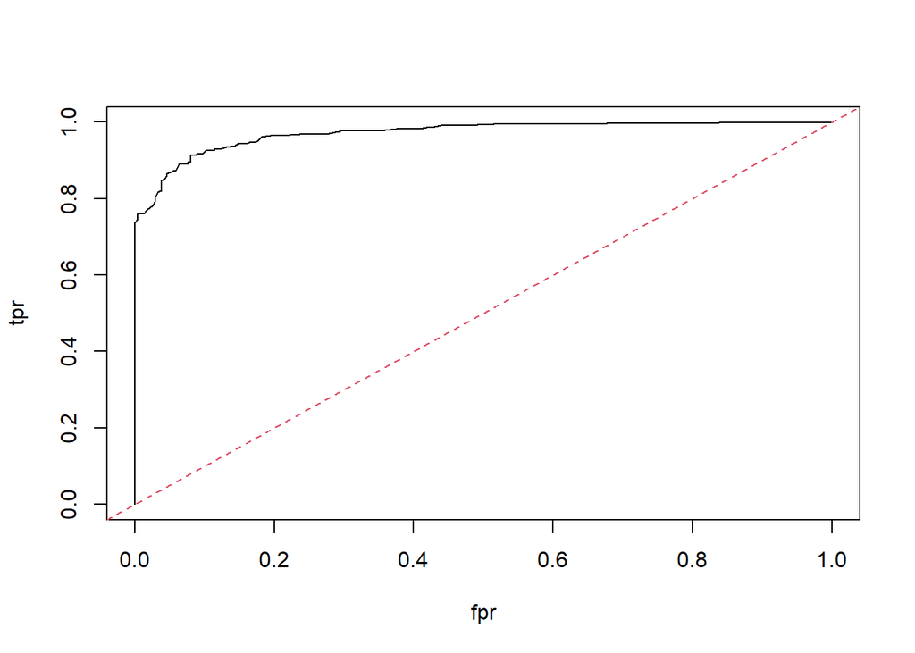

```r
# Load eval set
dfeval <- read.csv('https://raw.githubusercontent.com/letisalba/Data_621/master/Homework_3/csv/crime-evaluation-data_modified.csv')

# Summary
summary(dfeval)
```

```
##        zn             indus             chas           nox
##  Min.   : 0.000   Min.   : 1.760   Min.   :0.00   Min.   :0.3850
##  1st Qu.: 0.000   1st Qu.: 5.692   1st Qu.:0.00   1st Qu.:0.4713
##  Median : 0.000   Median : 8.915   Median :0.00   Median :0.5380
##  Mean   : 8.875   Mean   :11.507   Mean   :0.05   Mean   :0.5592
##  3rd Qu.: 0.000   3rd Qu.:18.100   3rd Qu.:0.00   3rd Qu.:0.6258
##  Max.   :90.000   Max.   :25.650   Max.   :1.00   Max.   :0.7400
##        rm             age              dis             rad
##  Min.   :3.561   Min.   :  6.80   Min.   :1.202   Min.   : 1.000
##  1st Qu.:5.874   1st Qu.: 56.62   1st Qu.:2.041   1st Qu.: 4.000
##  Median :6.143   Median : 83.25   Median :3.373   Median : 5.000
##  Mean   :6.214   Mean   : 70.99   Mean   :3.787   Mean   : 9.775
##  3rd Qu.:6.532   3rd Qu.: 93.10   3rd Qu.:4.527   3rd Qu.:24.000
##  Max.   :8.247   Max.   :100.00   Max.   :9.089   Max.   :24.000
##       tax           ptratio          lstat             medv
##  Min.   :188.0   Min.   :14.70   Min.   : 2.960   Min.   : 8.40
##  1st Qu.:276.8   1st Qu.:18.40   1st Qu.: 6.435   1st Qu.:16.98
##  Median :307.0   Median :19.60   Median :11.685   Median :20.55
##  Mean   :393.5   Mean   :19.12   Mean   :12.905   Mean   :21.88
##  3rd Qu.:666.0   3rd Qu.:20.20   3rd Qu.:17.363   3rd Qu.:25.00
##  Max.   :666.0   Max.   :21.20   Max.   :34.020   Max.   :50.00
```

```r
describe(dfeval)
```

```
##         vars  n   mean     sd median trimmed   mad    min    max  range  skew
## zn         1 40   8.88  22.97   0.00    2.25  0.00   0.00  90.00  90.00  2.59
## indus      2 40  11.51   7.11   8.91   11.21  8.87   1.76  25.65  23.89  0.32
## chas       3 40   0.05   0.22   0.00    0.00  0.00   0.00   1.00   1.00  3.98
## nox        4 40   0.56   0.11   0.54    0.55  0.11   0.38   0.74   0.36  0.40
## rm         5 40   6.21   0.68   6.14    6.21  0.43   3.56   8.25   4.69 -0.65
## age        6 40  70.99  26.27  83.25   74.06 20.31   6.80 100.00  93.20 -0.78
## dis        7 40   3.79   2.12   3.37    3.48  1.98   1.20   9.09   7.89  1.05
## rad        8 40   9.78   9.06   5.00    9.06  4.45   1.00  24.00  23.00  0.84
## tax        9 40 393.50 177.33 307.00  382.94 97.11 188.00 666.00 478.00  0.73
## ptratio   10 40  19.12   1.63  19.60   19.34  0.89  14.70  21.20   6.50 -1.17
## lstat     11 40  12.90   7.67  11.68   12.11  8.23   2.96  34.02  31.06  0.81
## medv      12 40  21.88   8.77  20.55   20.85  6.60   8.40  50.00  41.60  1.37
##         kurtosis    se
## zn          5.55  3.63
## indus      -1.32  1.12
## chas       14.16  0.03
## nox        -1.08  0.02
## rm          5.13  0.11
## age        -0.63  4.15
## dis         0.12  0.33
## rad        -1.15  1.43
## tax        -1.23 28.04
## ptratio     0.92  0.26
## lstat      -0.11  1.21
## medv        2.32  1.39
```

```r
# Make predictions on eval set
dfeval$pred_odds <- predict(lmod.fwd, newdata=dfeval)
dfeval$pred_p <- ilogit(dfeval$pred_odds)
dfeval$pred_target <- ifelse(dfeval$pred_p > 0.5, 1, 0)
dfeval$pred_target <- factor(dfeval$pred_target, levels=c(0, 1), labels=c('below_median', 'above_median'))
dfeval
```

```
##    zn indus chas   nox    rm   age    dis rad tax ptratio lstat medv
## 1   0  7.07    0 0.469 7.185  61.1 4.9671   2 242    17.8  4.03 34.7
## 2   0  8.14    0 0.538 6.096  84.5 4.4619   4 307    21.0 10.26 18.2
## 3   0  8.14    0 0.538 6.495  94.4 4.4547   4 307    21.0 12.80 18.4
## 4   0  8.14    0 0.538 5.950  82.0 3.9900   4 307    21.0 27.71 13.2
## 5   0  5.96    0 0.499 5.850  41.5 3.9342   5 279    19.2  8.77 21.0
## 6  25  5.13    0 0.453 5.741  66.2 7.2254   8 284    19.7 13.15 18.7
## 7  25  5.13    0 0.453 5.966  93.4 6.8185   8 284    19.7 14.44 16.0
## 8   0  4.49    0 0.449 6.630  56.1 4.4377   3 247    18.5  6.53 26.6
## 9   0  4.49    0 0.449 6.121  56.8 3.7476   3 247    18.5  8.44 22.2
## 10  0  2.89    0 0.445 6.163  69.6 3.4952   2 276    18.0 11.34 21.4
## 11  0 25.65    0 0.581 5.856  97.0 1.9444   2 188    19.1 25.41 17.3
## 12  0 25.65    0 0.581 5.613  95.6 1.7572   2 188    19.1 27.26 15.7
## 13  0 21.89    0 0.624 5.637  94.7 1.9799   4 437    21.2 18.34 14.3
## 14  0 19.58    0 0.605 6.101  93.0 2.2834   5 403    14.7  9.81 25.0
```

[output cut: 67 more lines]